# Assignment_3_478

## Assignment 3

#### CSC478

#### Brian Craft

```python
import csv as csv
import pandas as pd
import numpy as np
import os as os
import matplotlib.pyplot as pl
%matplotlib inline
from sklearn import cluster
from sklearn.cross_validation import KFold
from sklearn.linear_model import LinearRegression, Lasso, Ridge, ElasticNet, SGDRegressor
from sklearn import feature_selection
from sklearn.cross_validation import train_test_split
from sklearn import preprocessing
from sklearn.grid_search import GridSearchCV
from sklearn.preprocessing import StandardScaler
import matplotlib.pyplot as plt
from sklearn import cross_validation
from sklearn import metrics
from sklearn.linear_model import LinearRegression, Lasso, Ridge, ElasticNet, SGDRegressor
import pylab as pl
from sklearn.cluster import KMeans
from sklearn.naive_bayes import MultinomialNB
from sklearn.pipeline import Pipeline
from sklearn.feature_extraction.text import TfidfVectorizer
from sklearn.metrics import completeness_score, homogeneity_score
```

```python
os.chdir('/Users/Brian/Desktop/Assignment_3')
#os.chdir('C:/Users/bcraft/Downloads/Desktop/Assignment_3')
```

## Problem 1

### Part A

#### Load and preprocess the data using Pandas or Numpy and, if necessary, preprocessing functions from scikit-learn.

The communities data is loaded, with missing vlaues being replaced.

```python
data = pd.read_csv('communities.csv', na_values=["?"])
```

```python
data.shape
```

```
(1994, 100)
```

```python
data.head()
```

|  | state | communityname | population | householdsize | racepctblack | racePctWhite | racePctAsian | racePctHisp | agePct12t21 | agePct12t29 | ... | NumStreet | PctForeignBorn | PctBornSameState | PctSameHouse85 | PctSameCity85 | PctSameState85 | LandArea | PopDens | PctUsePubTrans | ViolentCrimesPerPop |
| --- | --- | --- | --- | --- | --- | --- | --- | --- | --- | --- | --- | --- | --- | --- | --- | --- | --- | --- | --- | --- | --- |
| 0 | 8 | Lakewoodcity | 0.19 | 0.33 | 0.02 | 0.90 | 0.12 | 0.17 | 0.34 | 0.47 | ... | 0 | 0.12 | 0.42 | 0.50 | 0.51 | 0.64 | 0.12 | 0.26 | 0.20 | 0.20 |
| 1 | 53 | Tukwilacity | 0.00 | 0.16 | 0.12 | 0.74 | 0.45 | 0.07 | 0.26 | 0.59 | ... | 0 | 0.21 | 0.50 | 0.34 | 0.60 | 0.52 | 0.02 | 0.12 | 0.45 | 0.67 |
| 2 | 24 | Aberdeentown | 0.00 | 0.42 | 0.49 | 0.56 | 0.17 | 0.04 | 0.39 | 0.47 | ... | 0 | 0.14 | 0.49 | 0.54 | 0.67 | 0.56 | 0.01 | 0.21 | 0.02 | 0.43 |
| 3 | 34 | Willingborotownship | 0.04 | 0.77 | 1.00 | 0.08 | 0.12 | 0.10 | 0.51 | 0.50 | ... | 0 | 0.19 | 0.30 | 0.73 | 0.64 | 0.65 | 0.02 | 0.39 | 0.28 | 0.12 |
| 4 | 42 | Bethlehemtownship | 0.01 | 0.55 | 0.02 | 0.95 | 0.09 | 0.05 | 0.38 | 0.38 | ... | 0 | 0.11 | 0.72 | 0.64 | 0.61 | 0.53 | 0.04 | 0.09 | 0.02 | 0.03 |

5 rows × 100 columns

```python
data = data.drop('communityname',1)
```

```python
data = data.drop('state', 1)
```

```python
data.isnull().values.any()
```

```
True
```

```python
data = data.fillna(data.mean())
```

```python
data.isnull().values.any()
```

```
False
```

#### Compute and display basic statistics (mean, standard deviation, min, max, etc.) for each of the variables in the data set.

The summary statistics for the variables is displayed below.

```python
means = data.mean(axis=0)
```

```python
means
```

```
population               0.057593
householdsize            0.463395
racepctblack             0.179629
racePctWhite             0.753716
racePctAsian             0.153681
racePctHisp              0.144022
agePct12t21              0.424218
agePct12t29              0.493867
agePct16t24              0.336264
agePct65up               0.423164
numbUrban                0.064072
pctUrban                 0.696269
medIncome                0.361123
pctWWage                 0.558154
pctWFarmSelf             0.291570
pctWInvInc               0.495687
pctWSocSec               0.471133
pctWPubAsst              0.317778
pctWRetire               0.479248
medFamInc                0.375677
perCapInc                0.350251
whitePerCap              0.368049
blackPerCap              0.291098
indianPerCap             0.203506
AsianPerCap              0.322357
OtherPerCap              0.284742
HispPerCap               0.386279
NumUnderPov              0.055507
PctPopUnderPov           0.303024
PctLess9thGrade          0.315807
                           ...
MedNumBR                 0.314694
HousVacant               0.076815
PctHousOccup             0.719549
PctHousOwnOcc            0.548686
PctVacantBoarded         0.204529
PctVacMore6Mos           0.433335
MedYrHousBuilt           0.494178
PctHousNoPhone           0.264478
PctWOFullPlumb           0.243059
OwnOccLowQuart           0.264689
OwnOccMedVal             0.263490
OwnOccHiQuart            0.268942
RentLowQ                 0.346379
RentMedian               0.372457
RentHighQ                0.422964
MedRent                  0.384102
MedRentPctHousInc        0.490125
MedOwnCostPctInc         0.449754
MedOwnCostPctIncNoMtg    0.403816
NumInShelters            0.029438
NumStreet                0.022778
PctForeignBorn           0.215552
PctBornSameState         0.608892
PctSameHouse85           0.535050
PctSameCity85            0.626424
PctSameState85           0.651530
LandArea                 0.065231
PopDens                  0.232854
PctUsePubTrans           0.161685
ViolentCrimesPerPop      0.237979
dtype: float64
```

```python
mins = data.min(axis=0)
```

```python
mins
```

```
population               0
householdsize            0
racepctblack             0
racePctWhite             0
racePctAsian             0
racePctHisp              0
agePct12t21              0
agePct12t29              0
agePct16t24              0
agePct65up               0
numbUrban                0
pctUrban                 0
medIncome                0
pctWWage                 0
pctWFarmSelf             0
pctWInvInc               0
pctWSocSec               0
pctWPubAsst              0
pctWRetire               0
medFamInc                0
perCapInc                0
whitePerCap              0
blackPerCap              0
indianPerCap             0
AsianPerCap              0
OtherPerCap              0
HispPerCap               0
NumUnderPov              0
PctPopUnderPov           0
PctLess9thGrade          0
                        ..
MedNumBR                 0
HousVacant               0
PctHousOccup             0
PctHousOwnOcc            0
PctVacantBoarded         0
PctVacMore6Mos           0
MedYrHousBuilt           0
PctHousNoPhone           0
PctWOFullPlumb           0
OwnOccLowQuart           0
OwnOccMedVal             0
OwnOccHiQuart            0
RentLowQ                 0
RentMedian               0
RentHighQ                0
MedRent                  0
MedRentPctHousInc        0
MedOwnCostPctInc         0
MedOwnCostPctIncNoMtg    0
NumInShelters            0
NumStreet                0
PctForeignBorn           0
PctBornSameState         0
PctSameHouse85           0
PctSameCity85            0
PctSameState85           0
LandArea                 0
PopDens                  0
PctUsePubTrans           0
ViolentCrimesPerPop      0
dtype: float64
```

```python
maxs = data.max(axis=0)
```

```python
maxs
```

```
population               1
householdsize            1
racepctblack             1
racePctWhite             1
racePctAsian             1
racePctHisp              1
agePct12t21              1
agePct12t29              1
agePct16t24              1
agePct65up               1
numbUrban                1
pctUrban                 1
medIncome                1
pctWWage                 1
pctWFarmSelf             1
pctWInvInc               1
pctWSocSec               1
pctWPubAsst              1
pctWRetire               1
medFamInc                1
perCapInc                1
whitePerCap              1
blackPerCap              1
indianPerCap             1
AsianPerCap              1
OtherPerCap              1
HispPerCap               1
NumUnderPov              1
PctPopUnderPov           1
PctLess9thGrade          1
                        ..
MedNumBR                 1
HousVacant               1
PctHousOccup             1
PctHousOwnOcc            1
PctVacantBoarded         1
PctVacMore6Mos           1
MedYrHousBuilt           1
PctHousNoPhone           1
PctWOFullPlumb           1
OwnOccLowQuart           1
OwnOccMedVal             1
OwnOccHiQuart            1
RentLowQ                 1
RentMedian               1
RentHighQ                1
MedRent                  1
MedRentPctHousInc        1
MedOwnCostPctInc         1
MedOwnCostPctIncNoMtg    1
NumInShelters            1
NumStreet                1
PctForeignBorn           1
PctBornSameState         1
PctSameHouse85           1
PctSameCity85            1
PctSameState85           1
LandArea                 1
PopDens                  1
PctUsePubTrans           1
ViolentCrimesPerPop      1
dtype: float64
```

```python
stdv = data.std(axis=0)
```

```python
stdv
```

```
population               0.126906
householdsize            0.163717
racepctblack             0.253442
racePctWhite             0.244039
racePctAsian             0.208877
racePctHisp              0.232492
agePct12t21              0.155196
agePct12t29              0.143564
agePct16t24              0.166505
agePct65up               0.179185
numbUrban                0.128256
pctUrban                 0.444811
medIncome                0.209362
pctWWage                 0.182913
pctWFarmSelf             0.204108
pctWInvInc               0.178071
pctWSocSec               0.173619
pctWPubAsst              0.222137
pctWRetire               0.167564
medFamInc                0.198257
perCapInc                0.191109
whitePerCap              0.186804
blackPerCap              0.171593
indianPerCap             0.164775
AsianPerCap              0.195411
OtherPerCap              0.190960
HispPerCap               0.183081
NumUnderPov              0.127941
PctPopUnderPov           0.228474
PctLess9thGrade          0.213360
                           ...
MedNumBR                 0.255182
HousVacant               0.150465
PctHousOccup             0.194024
PctHousOwnOcc            0.185204
PctVacantBoarded         0.217770
PctVacMore6Mos           0.188986
MedYrHousBuilt           0.232467
PctHousNoPhone           0.242847
PctWOFullPlumb           0.206295
OwnOccLowQuart           0.224425
OwnOccMedVal             0.231542
OwnOccHiQuart            0.235252
RentLowQ                 0.219323
RentMedian               0.209278
RentHighQ                0.248286
MedRent                  0.213404
MedRentPctHousInc        0.169500
MedOwnCostPctInc         0.187274
MedOwnCostPctIncNoMtg    0.192593
NumInShelters            0.102607
NumStreet                0.100400
PctForeignBorn           0.231134
PctBornSameState         0.204329
PctSameHouse85           0.181352
PctSameCity85            0.200521
PctSameState85           0.198221
LandArea                 0.109459
PopDens                  0.203092
PctUsePubTrans           0.229055
ViolentCrimesPerPop      0.232985
dtype: float64
```

#### Separate the target attribute for regression.

The target variable ViolentCrimesPerPop is seperated from the attributes and dropped.

```python
target = data['ViolentCrimesPerPop']
```

```python
train = data.drop('ViolentCrimesPerPop',1)
```

```python
labels = train.columns.values
```

```python
train = train.convert_objects(convert_numeric=True)
```

### Part B

#### Perform standard linear regression on data using the implementation for Ch. 8 of MLA.

The data is converted into a numpy array and a 1 column is added to represent the x0. The x and y variables are made to represent our attributes and target variable. Then, the standRegres function from MLA is used.

```python
target_ar = np.array(target)
```

```python
train_ar = np.array(train)
```

```python
x = np.array([np.concatenate((v,[1])) for v in train_ar])
```

```python
y = target_ar
```

```python
def standRegres(xArr,yArr):
    xMat = np.mat(xArr); yMat = np.mat(yArr).T
    xTx = xMat.T*xMat
    if np.linalg.det(xTx) == 0.0:
        print("This matrix is singular, cannot do inverse")
        return
    ws = xTx.I * (xMat.T*yMat)
    return ws
```

#### Compute the RMSE value on the full training data.

The RMSE is computed from the above function.

```python
w = standRegres(x,y)
```

```python
xMat=np.mat(x)
yMat=np.mat(y)
yHat = xMat*w
```

```python
yHatT = np.ravel(yHat.T)
```

```python
err = np.ravel(np.array(abs(yHatT - y)))
```

```python
total_error = np.dot(err,err)
rmse_train = np.sqrt(total_error/len(err))
print(rmse_train)
```

```
0.128889607798
```

#### Also, plot the correlation between the predicted and actual values of the target attribute.

Below is the correlation coefficient and the plot between y and yHat.

```python
np.corrcoef(yHatT, yMat)
```

```
array([[ 1.        ,  0.83294957],
       [ 0.83294957,  1.        ]])
```

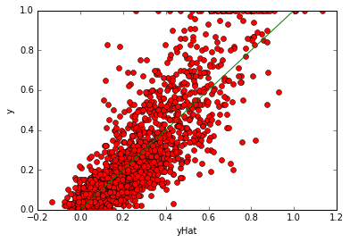

```python
pl.plot(yHat, y,'ro')
pl.plot([0,1],[0,1], 'g-')
pl.xlabel('yHat')
pl.ylabel('y')
pl.show()
```

#### Display the obtained regression coefficients (weights).

The regression coefficients w are displayed below.

```python
w
```

```
matrix([[  1.31108068e-01],
        [ -3.14114977e-02],
        [  2.09909670e-01],
        [ -4.05351612e-02],
        [ -1.38892919e-02],
        [  5.89726825e-02],
        [  1.23399025e-01],
        [ -2.22621600e-01],
        [ -1.47500199e-01],
        [  5.01635477e-02],
        [ -2.42413829e-01],
        [  4.64024392e-02],
        [ -1.96945615e-01],
        [ -2.06117500e-01],
        [  4.65935490e-02],
        [ -1.77212915e-01],
        [  6.30148504e-02],
        [  1.14942190e-02],
        [ -9.08951848e-02],
        [  2.74640044e-01],
        [  1.01752476e-01],
        [ -3.31517562e-01],
        [ -2.91799268e-02],
        [ -3.54483393e-02],
        [  2.26173855e-02],
        [  4.30950137e-02],
        [  3.44408548e-02],
        [  1.28412458e-01],
        [ -1.91293360e-01],
        [ -1.00769002e-01],
        [  6.46856092e-02],
        [  1.06062117e-01],
        [  2.44126002e-06],
        [  2.34984611e-01],
        [ -3.75705330e-02],
        [ -7.74957660e-03],
        [  4.66779619e-01],
        [  2.26295907e-01],
        [  1.74621953e-01],
        [ -5.75206227e-01],
```

[output cut: 43 more lines]

```
        [  3.74730887e-01],
        [  4.17402525e-02],
        [ -4.45747318e-02],
        [ -8.34683479e-02],
        [  1.30736305e-01],
        [  1.83468559e-01],
        [  1.26046949e-01],
        [  4.63490658e-03],
        [ -2.24577196e-02],
        [  2.88627319e-02],
        [  1.30622513e-02],
        [  2.76170980e-02],
        [ -1.24479622e-02],
        [ -3.73099899e-02],
        [  5.88079813e-01]])
```

#### Finally, perform 10-fold cross-validation using the learned model and compare the final RMSE to the training RMSE (for cross validation, you may use the KFold module from sklearn.cross_validation).

10 Fold Cross validation is performed using the learned model. To do this, I reused the weights from the learned function above.

```python
kf = KFold(len(x), n_folds=10)
xval_err = 0

for train,test in kf:

    xMat=np.mat(x[test])
    yMat=np.mat(y[test])
    yHat = np.ravel(xMat*w)
    err = abs(yHat - y[test])
    total_error = np.dot(err,err)
    xval_err += total_error

rmse_10cv = np.sqrt(xval_err/len(test))

method_name = 'Simple Linear Regression'
print'Method:', method_name
print'RMSE Training:', rmse_train
print'RMSE 10-fold CV:',rmse_10cv
```

```
Method: Simple Linear Regression
RMSE Training: 0.128889607798
RMSE 10-fold CV: 0.40799415462
```

### Part C

#### For feature selection, write a script or function to takes as input the training data and target attribute, the model, and any other parameters you find necessary, and returns the optimal percentage of the most informative features to use. Your approach should use k-fold cross-validation on the training data (you can use k=5). You can use feature_selection.SelectPercentile to find the most informative variables.

The below function takes inputs training data, target variable, the model, teh param value, the param name and the k to be used in cross validation. In this case the parameter is the percentile to be used for feature seleciton.

#### Next, plot the model's mean absolute error values on cross-validation relative to the percentage of selected features (See scikit-learn's metrics.mean_absolute_error). In order to use cross_validation.cross_val_score with regression you'll need to pass to it scoring='mean_absolute_error' as a parameter. [Hint: for an example of a similar feature selection process please review the class example notebook. Also, review scikit-learn documentation for feature selection.]

The percentiles used in the feature selection were plotted againt the cross validation scores using the cross_val_scores with the mean absolute error.

```python
from sklearn.cross_validation import KFold

def calc_params(x, y, regression, param_values, param_name, K):

    X = np.array(x)
    y = np.array(y)

    scores = []

    for i, param_value in enumerate(param_values):

        # set classifier parameters
        fs = feature_selection.SelectPercentile(feature_selection.f_regression, percentile=param_value)
        x_train_fs = fs.fit_transform(x, y)

        regression.fit(x_train_fs, y)

        k_scores = cross_validation.cross_val_score(regression,x_train_fs, y, scoring='mean_absolute_error', cv = K)

        mean_cv_score = np.mean(k_scores)

        scores.append(abs(mean_cv_score))

        print 'Percentile:',param_value
        print'CV Score:', abs(mean_cv_score)
        print '\n'

    # plot the training and testing scores in a log scale
    plt.plot(param_values, scores, label='CV Scores', alpha=0.4, lw=2, c='b')
    plt.legend(loc=7)
    plt.xlabel(param_name + " values")
    plt.ylabel("Mean CV Scores")
```

```python
param_values = np.linspace(1, 100, 50)
```

```python
regression = LinearRegression()
```

```python
name = 'Percentile'
```

```
Percentile: 1.0
CV Score: 0.114079092242


Percentile: 3.02040816327
CV Score: 0.103607697432


Percentile: 5.04081632653
CV Score: 0.101090355098


Percentile: 7.0612244898
CV Score: 0.101370525997


Percentile: 9.08163265306
CV Score: 0.101693434651


Percentile: 11.1020408163
CV Score: 0.101087385712


Percentile: 13.1224489796
CV Score: 0.101042970028


Percentile: 15.1428571429
CV Score: 0.101206613263


Percentile: 17.1632653061
CV Score: 0.100900253348


Percentile: 19.1836734694
CV Score: 0.100839721207


```

[output cut: 143 more lines]

```

Percentile: 93.9387755102
CV Score: 0.096867424823


Percentile: 95.9591836735
CV Score: 0.0968828262608


Percentile: 97.9795918367
CV Score: 0.0968301286468


Percentile: 100.0
CV Score: 0.0968752032537
```

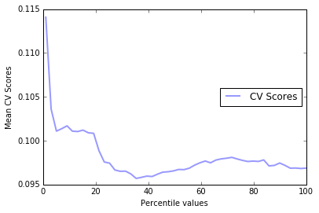

```python
calc_params(x, y, regression, param_values, name, 5)
```

#### Show the list of most informative variables and their weights [Note: since this is regression not classification, you should use feature_selection.f_regression as scoring function rather than chi2).

The best percentile appears to be right around 35 percent. Therefore, I created a new feature set using this percentile and printed out the labels. Please note this was done on the entire dataset.

```python
fs = feature_selection.SelectPercentile(feature_selection.f_regression, percentile=35)
x_train_fs = fs.fit_transform(x, y)
```

```python
for i in range(len(labels)):
    if fs.get_support()[i]:
        print labels[i],'\t', fs.scores_[i]
```

```
population 	310.369918779
racepctblack 	1319.68643314
racePctWhite 	1758.77227347
numbUrban 	302.12358082
medIncome 	437.1590743
pctWInvInc 	990.700974651
pctWPubAsst 	982.200467892
medFamInc 	475.837601763
perCapInc 	281.878264885
NumUnderPov 	499.025448645
PctPopUnderPov 	745.599159432
PctLess9thGrade 	405.110531951
PctNotHSGrad 	607.30932519
PctUnemployed 	679.145660493
MalePctDivorce 	759.581937457
FemalePctDiv 	891.494024673
TotalPctDiv 	876.510085951
PctFam2Par 	1987.05731023
PctKids2Par 	2388.61868809
PctYoungKids2Par 	1588.37986036
PctTeen2Par 	1550.53163637
NumIlleg 	567.975360335
PctIlleg 	2381.98320035
PctLargHouseFam 	343.442480513
PctPersOwnOccup 	759.916937383
PctPersDenseHous 	514.036224481
PctHousLess3BR 	578.789197875
MedNumBR 	291.680471184
HousVacant 	430.103642138
PctHousOwnOcc 	566.905240411
PctVacantBoarded 	605.507916549
PctHousNoPhone 	623.483263567
PctWOFullPlumb 	305.118590384
NumInShelters 	327.491789621
```

### Part D

#### First, create a 20%-80% randomized split of the data. Set aside the test portion; the model selection process should be performed using the 80% training data partition.

The data is split between test and training. Please note, the data was created using the data from the model selection process above.

```python
x_train, x_test, y_train, y_test = train_test_split(x_train_fs, y, test_size=0.2, random_state=33)
```

#### Ridge Regression and Lasso: You should create a function that takes as input the data and target attribute; the parameter to vary and a list of its values, the model to be trained, and any other relevant input needed to determine the optimal value for the specified parameter. The model selection process should perform k-fold cross validation (k should be a parameter, but you can select k=5 for this problem).

The below function takes the the attributes, target variable, list of parameters to be varied, the name of the paramater and the model to be used for training. In this case, the model takes Lasso and Ride. The model will read in the data, set an alpha value, and perform k fold cross validation. The CV portion will divide the data into training and test and for each fold the RMSE is calcualted for the training and test portions. The average RMSE for test and training is then stored and ploted against the param value.

#### You should also plot the error values on the training and cross-validation splits across the specified values of the alpha parameter.

The error values are ploted below.

```python
ridreg = Ridge()
lasreg = Lasso()
```

```python
alpha_range = np.linspace(0,10,1000)
ridge = Ridge()
lasso = Lasso()
```

```python
def get_params(x, y, param_name, k, param_range, model):

    train_scores = []
    test_scores = []

    for a in alpha_range:

        model.set_params(**{param_name:a})

        # initialize the K scores obtained for each fold
        k_train_scores = np.zeros(k)
        k_test_scores = np.zeros(k)

        # create KFold cross validation
        cv = KFold(len(x), k, shuffle=True, random_state=0)
        xval_err_train = 0
        xval_err_test = 0

        # iterate over the K folds
        kf = KFold(len(x), n_folds=k)
        xval_err_train = 0
        xval_err_test = 0

        for train,test in kf:

            xval_err_train = 0
            xval_err_test = 0

            model.fit(x[train],y[train])
            p_train = model.predict(x[train])
            e_train = p_train-y[train]
            xval_err_train += np.dot(e_train,e_train)

            p_test = model.predict(x[test])
            e_test = p_test-y[test]
            xval_err_test += np.dot(e_test,e_test)

        rmse_10cv_train = np.sqrt(xval_err_train/len(x))
        rmse_10cv_test = np.sqrt(xval_err_test/len(x))

        train_scores.append(rmse_10cv_train)
        test_scores.append(rmse_10cv_test)

        print "Alpha:",a
        print "RMSE CV Train:", rmse_10cv_train
        print "RMSE CV Test:", rmse_10cv_test
        print '\n'


    pl.plot(alpha_range, train_scores, label='RMSE-Train')
    pl.plot(alpha_range, test_scores, label='RMSE_XVal')
    pl.legend( ('RMSE-Train', 'RMSE_XVal') )
    pl.ylabel('RMSE')
    pl.xlabel('Alpha')
    pl.show()
```

The model is run using the ridge regression

```
Alpha: 0.0
RMSE CV Train: 0.117006389738
RMSE CV Test: 0.0640287280051


Alpha: 0.01001001001
RMSE CV Train: 0.11701206888
RMSE CV Test: 0.0640303060043


Alpha: 0.02002002002
RMSE CV Train: 0.117022164501
RMSE CV Test: 0.0640407950717


Alpha: 0.03003003003
RMSE CV Train: 0.117033301165
RMSE CV Test: 0.0640519754632


Alpha: 0.04004004004
RMSE CV Train: 0.117044672198
RMSE CV Test: 0.0640621367729


Alpha: 0.0500500500501
RMSE CV Train: 0.117056003328
RMSE CV Test: 0.0640709699773


Alpha: 0.0600600600601
RMSE CV Train: 0.117067177973
RMSE CV Test: 0.0640785280491


Alpha: 0.0700700700701
RMSE CV Train: 0.117078141019
RMSE CV Test: 0.0640849550487


```

[output cut: 4943 more lines]

```


Alpha: 9.97997997998
RMSE CV Train: 0.119492404143
RMSE CV Test: 0.0644295983716


Alpha: 9.98998998999
RMSE CV Train: 0.11949365074
RMSE CV Test: 0.0644299953418


Alpha: 10.0
RMSE CV Train: 0.119494896486
RMSE CV Test: 0.0644303922029
```

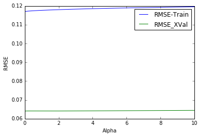

```python
get_params(x_train, y_train, "alpha", 5, alpha_range, ridge)
```

The model is run using the Lasso.

```
Alpha: 0.0
RMSE CV Train: 0.117011096656
RMSE CV Test: 0.064013683431


Alpha: 0.01001001001
RMSE CV Train: 0.134706694683
RMSE CV Test: 0.0718269115687


Alpha: 0.02002002002
RMSE CV Train: 0.155421183268
RMSE CV Test: 0.0831089999447


Alpha: 0.03003003003
RMSE CV Train: 0.180705932464
RMSE CV Test: 0.0971919420518


Alpha: 0.04004004004
RMSE CV Train: 0.203537484487
RMSE CV Test: 0.109677707831


Alpha: 0.0500500500501
RMSE CV Train: 0.203537484487
RMSE CV Test: 0.109677707831


Alpha: 0.0600600600601
RMSE CV Train: 0.203537484487
RMSE CV Test: 0.109677707831


Alpha: 0.0700700700701
RMSE CV Train: 0.203537484487
RMSE CV Test: 0.109677707831


```

[output cut: 4943 more lines]

```


Alpha: 9.97997997998
RMSE CV Train: 0.203537484487
RMSE CV Test: 0.109677707831


Alpha: 9.98998998999
RMSE CV Train: 0.203537484487
RMSE CV Test: 0.109677707831


Alpha: 10.0
RMSE CV Train: 0.203537484487
RMSE CV Test: 0.109677707831
```

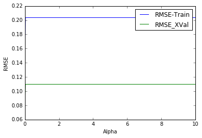

```python
get_params(x_train, y_train, "alpha", 5, alpha_range, lasso)
```

#### Finally, using the best alpha value, run the model on the set-aside test data. Discuss your observation and conclusions.

Below is the ridge regression with the alpha = 0 which proved to be the best model.

```python
ridge = Ridge(alpha = 0)
ridge.fit(x_train, y_train)
p = ridge.predict(x_test)
err = p - y_test
err2 = np.dot(err,err)
print "RMSE:",np.sqrt(err2/len(x_test))
```

```
RMSE: 0.143465457077
```

### Part E

#### Again, start with creating randomized 80%-20% train-test split.

Below a training and test set is remade.

```python
x_train, x_test, y_train, y_test = train_test_split(x, y, test_size=0.2, random_state=33)
```

#### SGDRegessor requires that features be standardized (with 0 mean and scaled by standard deviation). Prior to fiting the model, perform the scaling using StandardScaler from sklearn.preprocessing.

To accomodate the needs of the function, the variables are fit to standard scalars, both training and test.

```python
scaler = StandardScaler()
scaler.fit(x)
x_s_train = scaler.transform(x_train)
x_s_test = scaler.transform(x_test)
```

#### Your grid search should compare combinations of two penalty parameters ('l2', 'l1') and different values of alpha (alpha could vary from 0.0001 which is the default to relatively large values). Using the best parameters, apply the model to the set-aside test data.

Next, the paramaters are set for the regressor and the grid search is run.

```python
sgdreg = SGDRegressor()

parameters = {
    'penalty': [ 'l2', 'l1' ],
    'alpha': np.linspace(0,1,1000),
    'n_iter': [ 200 ]
}

gs = GridSearchCV(sgdreg, parameters, verbose=1, cv=5)
```

```python
%time _ = gs.fit(x_s_train, y_train)

gs.best_params_, gs.best_score_
```

```
Fitting 5 folds for each of 2000 candidates, totalling 10000 fits
```

```
[Parallel(n_jobs=1)]: Done  49 tasks       | elapsed:    8.5s
[Parallel(n_jobs=1)]: Done 199 tasks       | elapsed:   36.5s
[Parallel(n_jobs=1)]: Done 449 tasks       | elapsed:  1.4min
[Parallel(n_jobs=1)]: Done 799 tasks       | elapsed:  2.5min
[Parallel(n_jobs=1)]: Done 1249 tasks       | elapsed:  3.9min
[Parallel(n_jobs=1)]: Done 1799 tasks       | elapsed:  5.6min
[Parallel(n_jobs=1)]: Done 2449 tasks       | elapsed:  7.6min
[Parallel(n_jobs=1)]: Done 3199 tasks       | elapsed: 10.0min
[Parallel(n_jobs=1)]: Done 4049 tasks       | elapsed: 12.6min
[Parallel(n_jobs=1)]: Done 4999 tasks       | elapsed: 15.6min
[Parallel(n_jobs=1)]: Done 6049 tasks       | elapsed: 18.9min
[Parallel(n_jobs=1)]: Done 7199 tasks       | elapsed: 22.5min
[Parallel(n_jobs=1)]: Done 8449 tasks       | elapsed: 26.4min
[Parallel(n_jobs=1)]: Done 9799 tasks       | elapsed: 30.6min
```

```
CPU times: user 1h 48s, sys: 19.4 s, total: 1h 1min 8s
Wall time: 31min 13s
```

```
[Parallel(n_jobs=1)]: Done 10000 out of 10000 | elapsed: 31.2min finished
```

```
({'alpha': 0.025025025025025023, 'n_iter': 200, 'penalty': 'l2'},
 0.66453997955016209)
```

```python
sgdreg = SGDRegressor(penalty='elasticnet', alpha=0, n_iter=200, l1_ratio=0.6645)
sgdreg.fit(x_train,y_train)
p = sgdreg.predict(x_test)
err = p-y_test
total_error = np.dot(err,err)
rmse_train = np.sqrt(total_error/len(p))
method_name = 'Stochastic Gradient Descent Regression'

print('Method: %s' %method_name)
print('RMSE on training: %.4f' %rmse_train)
```

```
Method: Stochastic Gradient Descent Regression
RMSE on training: 0.1452
```

#### Finally, perform model selection (similar to part d, above) to find the best "l1_ratio" parameter using SGDRegressor with the "elasticnet" penalty parameter.

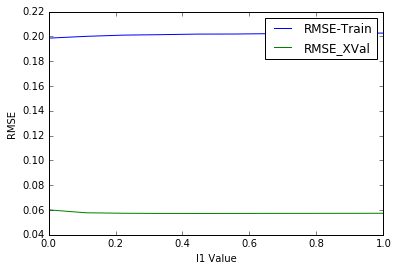

```python
l1_ratio_range = np.linspace(0,1,10)
train_scores = []
test_scores = []

for i in l1_ratio_range:

        sgdreg = SGDRegressor(penalty='elasticnet', alpha=.02, n_iter=200, l1_ratio=i)

        kf = KFold(len(x_s_train), n_folds=10)
        xval_err_train = 0
        xval_err_test = 0

        for train,test in kf:

            xval_err_train = 0
            xval_err_test = 0

            sgdreg.fit(x_s_train[train],y[train])
            p_train = sgdreg.predict(x_s_train[train])
            e_train = p_train-y[train]
            xval_err_train += np.dot(e_train,e_train)

            p_test = sgdreg.predict(x_s_train[test])
            e_test = p_test-y[test]
            xval_err_test += np.dot(e_test,e_test)

        rmse_10cv_train = np.sqrt(xval_err_train/len(x))
        rmse_10cv_test = np.sqrt(xval_err_test/len(x))

        train_scores.append(rmse_10cv_train)
        test_scores.append(rmse_10cv_test)

pl.plot(l1_ratio_range, train_scores, label='RMSE-Train')
pl.plot(l1_ratio_range, test_scores, label='RMSE_XVal')
pl.legend( ('RMSE-Train', 'RMSE_XVal') )
pl.ylabel('RMSE')
pl.xlabel('l1 Value')
pl.show()
```

## Problem 2

### Part B

#### Load the data set [Note: the data matrix provided has terms as rows and documents as columns. Since you will be clustering documents, you'll need to take the transpose of this matrix so that your main data matrix is a document x term matrix. In Numpy, you may use the ".T" operation to obtain the transpose.]

The data is loaded and transposed. As well, the classes are loaded.

```python
tf = pd.read_csv('matrix.txt', na_values=["?"], dtype = int, header = None)
```

```python
tf_ar =np.array(tf).T
```

```python
tf = pd.DataFrame(tf_ar)
```

```python
classes = pd.read_csv('classes.txt', skiprows = [0], na_values=["?"], index_col = 0 , delim_whitespace=True, header = None)
```

#### Then, split the data set (the document x term matrix) and set aside 20% for later use (see below). Use the 80% segment for clustering in the next part. The 20% portion must be a random subset.

The data is then split into training and test.

```python
x_train, x_test, y_train, y_test = train_test_split(tf, classes, test_size=0.2, random_state=33)
```

### Part C

#### As in the case of Assignment 2, transform the term-frequencies to tfxidf values. Be sure to maintain DF values for each of the terms in the dictionary.

The tf matrix is converted to TF IDF matrix. Any missing values are replaced with 0.

```python
x_train_ar = np.array(x_train)
x_test_ar = np.array(x_test)
```

```python
numTerms = len(x_train_ar[1])
```

```python
numDocsTrain = len(x_train_ar)
```

```python
termFreqs = x_train_ar.sum(axis=0)
```

```python
DocFreq = np.array([(x_train_ar!=0).sum(0)])
```

```python
matrix_train = np.ones(np.shape(x_train_ar), dtype=float)*numDocsTrain
matrix_test = np.ones(np.shape(x_test_ar), dtype=float)*numDocsTrain
np.set_printoptions(precision=2,suppress=True,linewidth=120)
```

```python
train_IDF = np.log2(np.divide(matrix_train,DocFreq))
test_IDF = np.log2(np.divide(matrix_test,DocFreq))
```

```python
train_TFIDF = x_train_ar * train_IDF
test_TFIDF = x_test_ar * test_IDF
```

```python
where_are_train = np.isnan(train_TFIDF)
train_TFIDF[where_are_train] = 0
```

```python
where_are_test = np.isnan(test_TFIDF)
test_TFIDF[where_are_test] = 0
```

### Part D

#### Perform Kmeans clustering on the training data.

Using the KMeans function with the altered Cosine Similarity, clustering is performed. As well, TF IDF values are used.

```python
from numpy import *
import kMeans
```

```python
reload(kMeans)
```

```
<module 'kMeans' from 'kMeans.pyc'>
```

```python
centroids, clusters = kMeans.kMeans(train_TFIDF, 5)
```

#### Write a function to display the top N terms in each cluster along with the cluster DF values for each term, percentage of docs in the cluster in which the terms appear, and the size of the cluster. Sort the terms in decreasing order of the DF percentage.

The below function takes cluster centers, terms, the original term frequency matrix and the k to show. Keep in mind, the original untransforemd data was used so term frequencies are shown and not TF IDF values. As well, the term frequencies, doc freqs and df percentages are shown. Cluster sizes are also shown.

```python
#Get all the necessary inputs for my function
terms = pd.read_csv('terms.txt', na_values=["?"], dtype = str, header = None)
terms = ravel(np.array(terms))
terms_df = pd.DataFrame(terms)
x = np.array(x_train)
```

```python
def cluster_info(clusters, terms_df, x, k):

    global final_0
    global final_1
    global final_2
    global final_3
    global final_4

    #Get the clsuter sizes
    counter_0 = 0
    counter_1 = 0
    counter_2 = 0
    counter_3 = 0
    counter_4 = 0

    observations_cluster = {}
    observations_tf = {}

    cluster_0_tf = np.zeros(shape=[9328,])
    cluster_1_tf = np.zeros(shape=[9328,])
    cluster_2_tf = np.zeros(shape=[9328,])
    cluster_3_tf = np.zeros(shape=[9328,])
    cluster_4_tf = np.zeros(shape=[9328,])

    cluster_0_df = np.zeros(shape=[9328,])
    cluster_1_df = np.zeros(shape=[9328,])
    cluster_2_df = np.zeros(shape=[9328,])
    cluster_3_df = np.zeros(shape=[9328,])
    cluster_4_df = np.zeros(shape=[9328,])

    #Get the cluster sizes
    for value in clusters:

        if value[0] == 0:
            counter_0 += 1

        if value[0] == 1:
            counter_1 += 1

        if value[0] == 2:
            counter_2 += 1

        if value[0] == 3:
            counter_3 += 1

        if value[0] == 4:
            counter_4 += 1


    #This gets the term frequencies for each cluster

    for i,value in enumerate(x):
        observations_tf[i] = value

    for i,value in enumerate(clusters):
        observations_cluster[i] = value[0]

    for key,value in observations_cluster.items():

        if value == 0:
            cluster_0_tf += observations_tf[key]

        if value == 1:
            cluster_1_tf += observations_tf[key]

        if value == 2:
            cluster_2_tf += observations_tf[key]

        if value == 3:
            cluster_3_tf += observations_tf[key]

        if value == 4:
            cluster_4_tf += observations_tf[key]

    #this gets the document frequencies
    for key,value in observations_cluster.items():

        if value == 0:

            lst = [1 if x > 0 else 0 for x in observations_tf[key]]
            cluster_0_df += lst

        if value == 1:

            lst = [1 if x > 0 else 0 for x in observations_tf[key]]
            cluster_1_df += lst

        if value == 2:

            lst = [1 if x > 0 else 0 for x in observations_tf[key]]
            cluster_2_df += lst

        if value == 3:

            lst = [1 if x > 0 else 0 for x in observations_tf[key]]
            cluster_3_df += lst

        if value == 4:

            lst = [1 if x > 0 else 0 for x in observations_tf[key]]
            cluster_4_df += lst

    cluster_0_tf_t = pd.DataFrame(cluster_0_tf.T)
    cluster_1_tf_t = pd.DataFrame(cluster_1_tf.T)
    cluster_2_tf_t = pd.DataFrame(cluster_2_tf.T)
    cluster_3_tf_t = pd.DataFrame(cluster_3_tf.T)
    cluster_4_tf_t = pd.DataFrame(cluster_4_tf.T)

    cluster_0_df_t = pd.DataFrame(cluster_0_df.T)
    cluster_1_df_t = pd.DataFrame(cluster_1_df.T)
    cluster_2_df_t = pd.DataFrame(cluster_2_df.T)
    cluster_3_df_t = pd.DataFrame(cluster_3_df.T)
    cluster_4_dt_t = pd.DataFrame(cluster_4_df.T)

    lst = [cluster_0_tf_t,
       cluster_1_tf_t,
       cluster_2_tf_t,
       cluster_3_tf_t,
       cluster_4_tf_t,
       cluster_0_df_t,
       cluster_1_df_t,
       cluster_2_df_t,
       cluster_3_df_t,
       cluster_4_dt_t]


    for item in lst:
        terms_df = terms_df.join(item, how = 'left', lsuffix = 'left')

    terms_df.columns = ['Term',
                   'cluster_0_tf',
                   'cluster_1_tf',
                   'cluster_2_tf',
                   'cluster_3_tf',
                   'cluster_4_tf',
                   'cluster_0_df',
                   'cluster_1_df',
                   'cluster_2_df',
                   'cluster_3_df',
                   'cluster_4_df']

    terms_df['cluster_0_df_percent'] = (terms_df['cluster_0_df'] / counter_0)
    terms_df['cluster_1_df_percent'] = (terms_df['cluster_1_df'] / counter_1)
    terms_df['cluster_2_df_percent'] = (terms_df['cluster_2_df'] / counter_2)
    terms_df['cluster_3_df_percent'] = (terms_df['cluster_3_df'] / counter_3)
    terms_df['cluster_4_df_percent'] = (terms_df['cluster_4_df'] / counter_4)

    final_0 = terms_df.loc[:,['Term', 'cluster_0_tf', 'cluster_0_df', 'cluster_0_df_percent']]
    final_1 = terms_df.loc[:,['Term', 'cluster_1_tf', 'cluster_1_df', 'cluster_1_df_percent']]
    final_2 = terms_df.loc[:,['Term', 'cluster_2_tf', 'cluster_2_df', 'cluster_2_df_percent']]
    final_3 = terms_df.loc[:,['Term', 'cluster_3_tf', 'cluster_3_df', 'cluster_3_df_percent']]
    final_4 = terms_df.loc[:,['Term', 'cluster_4_tf', 'cluster_4_df', 'cluster_4_df_percent']]


    print 'Cluster Sizes'
    print '\n'
    print 'Cluster 0:',counter_0
    print 'Cluster 1:',counter_1
    print 'Cluster 2:',counter_2
    print 'Cluster 3:',counter_3
    print 'Cluster 4:',counter_4
    print '\n'
    print 'Cluster Information'
    print '\n'

    print 'Cluster 0 Most Frequent Terms'
    print '\n'
    print final_0.sort(['cluster_0_df_percent'], ascending=False).head(k)
    print '\n'

    print 'Cluster 1 Most Frequent Terms'
    print '\n'
    print final_1.sort(['cluster_1_df_percent'], ascending=False).head(k)
    print '\n'

    print 'Cluster 2 Most Frequent Terms'
    print '\n'
    print final_2.sort(['cluster_2_df_percent'], ascending=False).head(k)
    print '\n'

    print 'Cluster 3 Most Frequent Terms'
    print '\n'
    print final_3.sort(['cluster_3_df_percent'], ascending=False).head(k)
    print '\n'

    print 'Cluster 4 Most Frequent Terms'
    print '\n'
    print final_4.sort(['cluster_4_df_percent'], ascending=False).head(k)
    print '\n'
```

```python
cluster_info(clusters, terms_df, x, 10)
```

```
Cluster Sizes


Cluster 0: 762
Cluster 1: 393
Cluster 2: 433
Cluster 3: 405
Cluster 4: 7


Cluster Information


Cluster 0 Most Frequent Terms


         Term  cluster_0_tf  cluster_0_df  cluster_0_df_percent
7895  subject           802           762              1.000000
9025   window           875           296              0.388451
9129    write           306           222              0.291339
5795       on           357           216              0.283465
8174    thank           224           213              0.279528
2550    email           250           210              0.275591
7115     sale           335           208              0.272966
6207    pleas           240           203              0.266404
3266      get           307           194              0.254593
9084     work           290           181              0.237533


Cluster 1 Most Frequent Terms


           Term  cluster_1_tf  cluster_1_df  cluster_1_df_percent
7895    subject           457           393              1.000000
9129      write           325           243              0.618321
5795         on           587           218              0.554707
3345        god           951           214              0.544529
417      articl           247           187              0.475827
1335  christian           592           179              0.455471
6049      peopl           422           173              0.440204
```

[output cut: 36 more lines]

```

Cluster 4 Most Frequent Terms


         Term  cluster_4_tf  cluster_4_df  cluster_4_df_percent
547        ax         45495             7              1.000000
7895  subject             7             7              1.000000
6534       qq            68             6              0.857143
5676     nrhj            36             6              0.857143
6183       pl           362             6              0.857143
5428      mwt            19             6              0.857143
9062       wm           104             6              0.857143
5426       mw            43             6              0.857143
5975     part            12             6              0.857143
9223       yd            34             6              0.857143
```

#### [Extra Credit: use your favorite third party tool, ideally with a Python based API, to create a word cloud for each cluster based on the in-cluster DF values.]

```python
from wordcloud import WordCloud
import matplotlib.pyplot as plt
%matplotlib inline
```

```python
wc0 = final_0.drop(final_0[final_0.cluster_0_tf < 1].index)
wc1 = final_1.drop(final_1[final_1.cluster_1_tf < 1].index)
wc2 = final_2.drop(final_2[final_2.cluster_2_tf < 1].index)
wc3 = final_3.drop(final_3[final_3.cluster_3_tf < 1].index)
wc4 = final_4.drop(final_4[final_4.cluster_4_tf < 1].index)
```

```python
wc00 = wc0['Term']
wc10 = wc1['Term']
wc20 = wc2['Term']
wc30 = wc3['Term']
wc40 = wc4['Term']
```

```python
wc000 = list((wc0['Term']))
wc100 = list((wc1['Term']))
wc200 = list((wc2['Term']))
wc300 = list((wc3['Term']))
wc400 = list((wc4['Term']))
```

```python
c0_string = ""
c1_string = ""
c2_string = ""
c3_string = ""
c4_string = ""

for i in wc000:
    c0_string += i + " "
for i in wc100:
    c1_string += i + " "
for i in wc200:
    c2_string += i + " "
for i in wc300:
    c3_string += i + " "
for i in wc400:
    c4_string += i + " "
```

```python
c0_cloud = WordCloud(background_color='white').generate(c0_string)
c1_cloud = WordCloud(background_color='white').generate(c1_string)
c2_cloud = WordCloud(background_color='white').generate(c2_string)
c3_cloud = WordCloud(background_color='white').generate(c3_string)
c4_cloud = WordCloud(background_color='white').generate(c4_string)
```

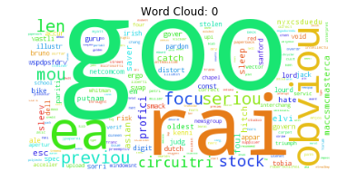

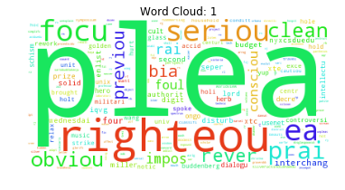

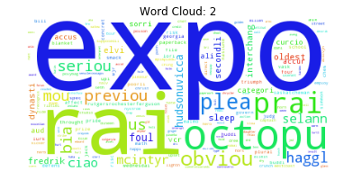

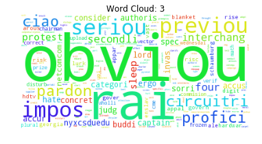

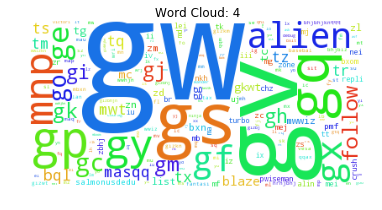

```python
plt.imshow(c0_cloud)
plt.axis('off')
plt.title('Word Cloud: 0')
plt.show()

plt.imshow(c1_cloud)
plt.axis('off')
plt.title('Word Cloud: 1')
plt.show()

plt.imshow(c2_cloud)
plt.axis('off')
plt.title('Word Cloud: 2')
plt.show()

plt.imshow(c3_cloud)
plt.axis('off')
plt.title('Word Cloud: 3')
plt.show()

plt.imshow(c4_cloud)
plt.axis('off')
plt.title('Word Cloud: 4')
plt.show()
```

### Part E

#### Using the cluster assignments from Kmeans clustering, compare your 5 clusters to the 5 pre-assigned classes by computing the Completeness and Homogeneity values.

Below the completeness and homogeneity are calcualted.

```python
#Get the cluster assignments in a list and convert to a dataframe
lst = []

for i in clusters:
    cla = i[0]
    lst.append(cla)

predicted_c = pd.DataFrame(lst)

#convert to a numpy array to havea the predicted classes
predicted = np.ravel(np.array(predicted_c))
```

```python
#get our training labels in a list of the same shape as above
train = np.ravel(np.array(y_train))
```

```python
print completeness_score(predicted,train)
```

```
0.686464803956
```

```python
print homogeneity_score(predicted,train)
```

```
0.811175594696
```

### Part F

#### Finally, using your cluster assignments as class labels, categorize each of the documents in the 20% set-aside data into each of the appropriate cluster. Your categorization should be based on Cosine similarity between each test document and each cluster centroids. Present your results in a separate file containing the obtained cluster label for each test document as well as Cosine similarities between each test document and each of the 5 clusters.

The below function takes the test TFIDF data and compares the distance to each centroid. The document is then put into a cluster. This function uses cosine similairty. Below a confusion matrix is created.

```python
test_labels = np.ravel(np.array(y_test))
```

```python
test_clusters = {}
rated = {}
pred_ratings = []

for i,array in enumerate(test_TFIDF):

    test_clusters[i] = []

    for i2, center in enumerate(centroids):

        cdistance =  1 - (np.dot(array,center) / (linalg.norm(array) * linalg.norm(center)) )
        test_clusters[i].append([i2,cdistance])


for key,value in test_clusters.items():

        value = sorted(value,key=lambda x:(-x[1],x[0]))
        pred = value[1][0]
        rated[key] = pred
        pred_ratings.append(pred)
```

```python
test_labels_pd = pd.DataFrame(test_labels)
pred_labels_pd = pd.DataFrame(pred_ratings)
final = test_labels_pd.join(pred_labels_pd, how = 'left', lsuffix = 'left')
final.columns = ['Actual_Group', 'Predicted_Group']
```

```python
final.loc[final.Predicted_Group == 0, 'Predicted_Group'] = "Window_Predicted"
final.loc[final.Predicted_Group == 1, 'Predicted_Group'] = "Christian_Predicted"
final.loc[final.Predicted_Group == 2, 'Predicted_Group'] = "Hockey_Predicted"
final.loc[final.Predicted_Group == 3, 'Predicted_Group'] = "Crypt_Predicted"
final.loc[final.Predicted_Group == 4, 'Predicted_Group'] = "ForSale_Predicted"

final.loc[final.Actual_Group == 0, 'Actual_Group'] = "Windows"
final.loc[final.Actual_Group == 1, 'Actual_Group'] = "Crypt"
final.loc[final.Actual_Group == 2, 'Actual_Group'] = "Christian"
final.loc[final.Actual_Group == 3, 'Actual_Group'] = "Hockey"
final.loc[final.Actual_Group == 4, 'Actual_Group'] = "ForSale"
```

```python
crosser = pd.crosstab(final['Actual_Group'], final['Predicted_Group'])
crosser
```

| Predicted_Group Actual_Group | Christian_Predicted | Crypt_Predicted | Hockey_Predicted | Window_Predicted |
| --- | --- | --- | --- | --- |
| Christian | 4 | 9 | 76 | 19 |
| Crypt | 22 | 0 | 70 | 2 |
| ForSale | 85 | 10 | 15 | 0 |
| Hockey | 67 | 18 | 0 | 13 |
| Windows | 45 | 0 | 44 | 1 |

### This puts the predicted Classes In a CSV File.

The data is then output into a CS file that contains the predicted class and the distance to each centroid.

```python
dict_pd = pd.DataFrame(test_clusters.items())
```

```python
final = final.join(dict_pd, how = 'left', lsuffix = 'left')
```

```python
final = final.drop(0, 1)
```

```python
final.columns = ['Actual_Grouping', 'Predicted_Grouping', 'Centroids_Cosine_Sim']
final.head()
```

|  | Actual_Grouping | Predicted_Grouping | Centroids_Cosine_Sim |
| --- | --- | --- | --- |
| 0 | Christian | Hockey_Predicted | [[0, 0.965059246479], [1, 0.907302346905], [2,... |
| 1 | Christian | Hockey_Predicted | [[0, 0.92688005971], [1, 0.881888013085], [2, ... |
| 2 | ForSale | Hockey_Predicted | [[0, 0.959521007169], [1, 0.97659906862], [2, ... |
| 3 | Windows | Hockey_Predicted | [[0, 0.778272978571], [1, 0.923227671564], [2,... |
| 4 | ForSale | Crypt_Predicted | [[0, 0.907033901605], [1, 0.959440527724], [2,... |

```python
final.to_csv('test_clusters.csv', sep=',')
```